# ANOVA for a RCBD trial: PTLB199909_OXAPMP_B3C1OXA00-03

rsimon using HIDAP

November 19, 2015, 11:15h

Author affiliations:

```r
# This is an automatedly created report.

# See more details in section on materials.
```

[output not shown]

# Abstract

# Materials and Methods

## Location characterization

### Installation

### Geographic and climate characterization

### Weather during planting season

### Soil

### Field management

### Observations on special events

## Materials

## Trait descriptions (from ontology)

## Model specification and data description

There is data from 26 treatments, evaluated using a randomize complete block design with 4 blocks. The statistical model is
$$y_{ij} = \mu + \tau_i + \beta_j + \epsilon_{ij}$$
where

- $y_{ij}$ is the observed response with treatment $i$ and block $j$.
- $\mu$ is the mean response over all treatments and blocks.
- $\tau_i$ is the effect for treatment $i$.
- $\beta_j$ is the effect for block $j$.
- $\epsilon_{ij}$ is the error term.

In this model we assume that the errors are independent and have a normal distribution with common variance, that is, $\epsilon_{ij} \sim N(0,\sigma_{\epsilon}^2)$.

The following traits are analyzed: **SG, FFR, TEXFR, Chip_Color, LB3**

## Computational tools

# Results

## Raw data

## Trait summaries

## Trait analyses

### Analysis for trait SG

You have fitted a linear model for a RCBD. The ANOVA table for your model is:

Table continues below

|  | Df | Sum Sq | Mean Sq | F value |
| --- | --- | --- | --- | --- |
| **INSTN** | 25 | 0.00658072 | 0.000263229 | 20.0055 |
| **REP** | 3 | 5.3854e-05 | 1.79513e-05 | 1.3643 |
| **Residuals** | 75 | 0.000986839 | 1.31579e-05 | NA |

|  | Pr(>F) |
| --- | --- |
| **INSTN** | 7.34552e-24 |
| **REP** | 0.260231 |
| **Residuals** | NA |

The p-value for treatments is 0.00000000000000000000000734552 which is significant at the 5% level.

The means of your treatments are:

| INSTN | SG |
| --- | --- |
| CIP377744.1 | 1.07 |
| CIP384866.5 | 1.05 |
| CIP391004.18 | 1.07 |
| CIP391011.17 | 1.08 |
| CIP391046.14 | 1.05 |
| CIP391047.34 | 1.06 |
| CIP391065.69 | 1.06 |
| CIP391580.30 | 1.07 |
| CIP392617.54 | 1.08 |
| CIP392634.49 | 1.07 |
| CIP392637.10 | 1.07 |
| CIP392639.31 | 1.05 |
| CIP392639.34 | 1.06 |
| CIP392640.18 | 1.07 |
| CIP392657.171 | 1.08 |
| CIP392657.8 | 1.06 |
| CIP393077.54 | 1.07 |
| CIP393079.24 | 1.07 |
| CIP393227.66 | 1.07 |
| CIP393248.55 | 1.07 |
| CIP393339.242 | 1.06 |
| CIP393371.58 | 1.08 |
| CIP393385.39 | 1.06 |
| CIP393385.47 | 1.07 |
| CIP393453.198 | 1.06 |
| CIP720064 | 1.05 |

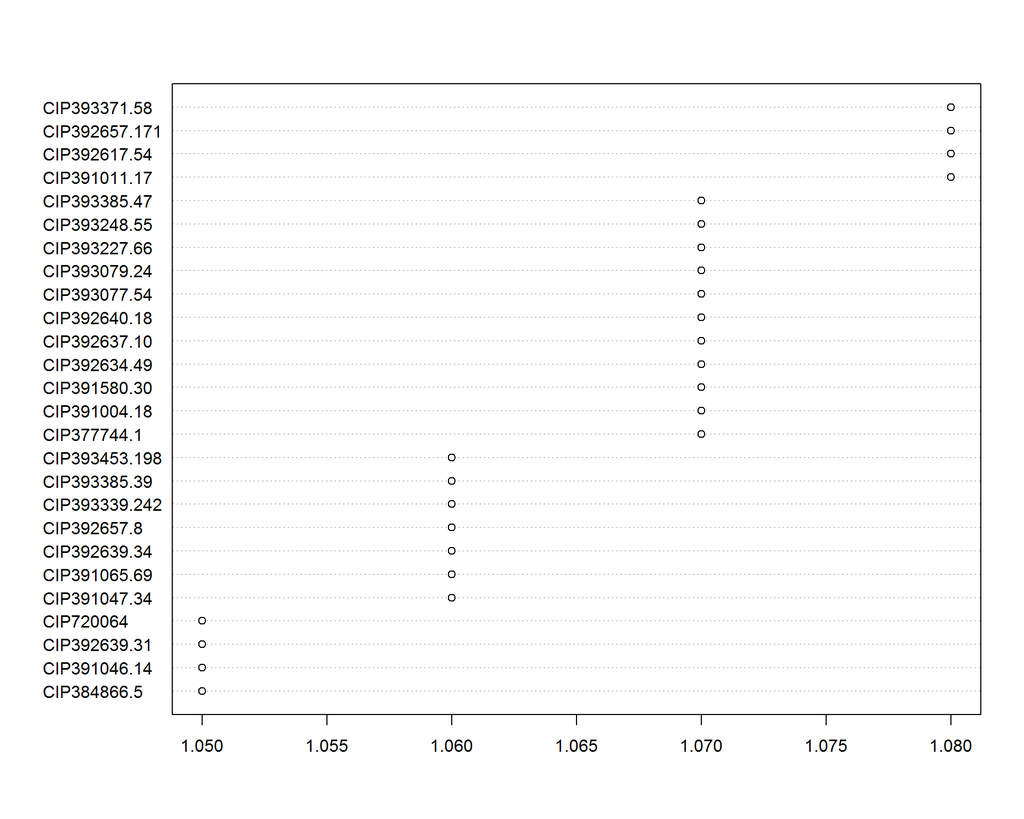

Do not forget the assumptions of the model. It is supposed that the error has a normal distribution with the same variance for all the treatments. The following plots must help you evaluate this:

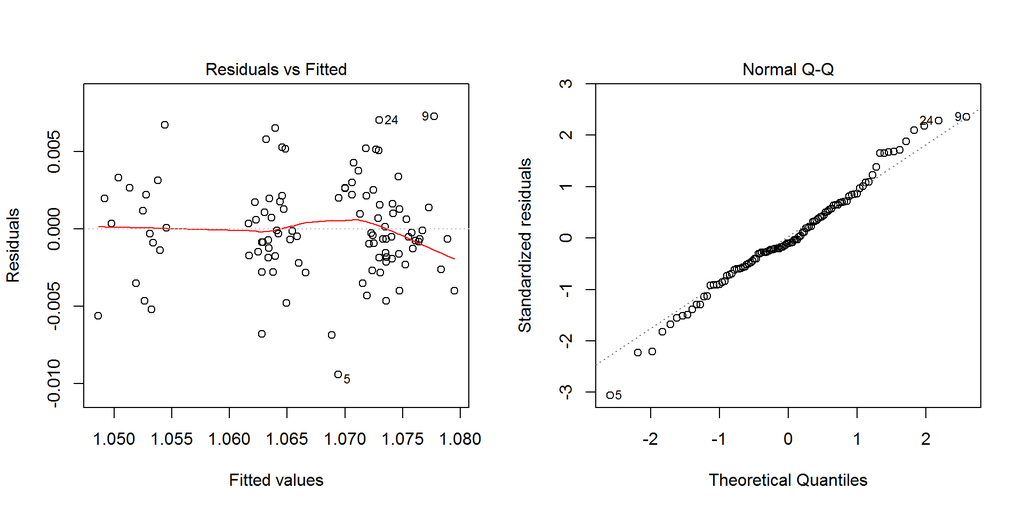

Funnel shapes for the first plot may suggest heterogeneity of variances while departures from the theoretical normal line are symptoms of lack of normality.

### Analysis for trait FFR

You have fitted a linear model for a RCBD. The ANOVA table for your model is:

|  | Df | Sum Sq | Mean Sq | F value | Pr(>F) |
| --- | --- | --- | --- | --- | --- |
| **INSTN** | 25 | 20.0202 | 0.800807 | 3.09729 | 8.48587e-05 |
| **REP** | 3 | 0.390444 | 0.130148 | 0.503374 | 0.681113 |
| **Residuals** | 75 | 19.3913 | 0.258551 | NA | NA |

The p-value for treatments is 0.0000848587 which is significant at the 5% level.

The means of your treatments are:

| INSTN | FFR |
| --- | --- |
| CIP377744.1 | 2.76 |
| CIP384866.5 | 2.66 |
| CIP391004.18 | 2.92 |
| CIP391011.17 | 2.4 |
| CIP391046.14 | 2.31 |
| CIP391047.34 | 1.98 |
| CIP391065.69 | 1.53 |
| CIP391580.30 | 1.68 |
| CIP392617.54 | 2.33 |
| CIP392634.49 | 1.86 |
| CIP392637.10 | 1.64 |
| CIP392639.31 | 2.54 |
| CIP392639.34 | 2.11 |
| CIP392640.18 | 1.37 |
| CIP392657.171 | 1.91 |
| CIP392657.8 | 1.26 |
| CIP393077.54 | 1.98 |
| CIP393079.24 | 1.77 |
| CIP393227.66 | 2.27 |
| CIP393248.55 | 1.64 |
| CIP393339.242 | 2.74 |
| CIP393371.58 | 2.48 |
| CIP393385.39 | 2.33 |
| CIP393385.47 | 2.35 |
| CIP393453.198 | 1.9 |
| CIP720064 | 1.81 |

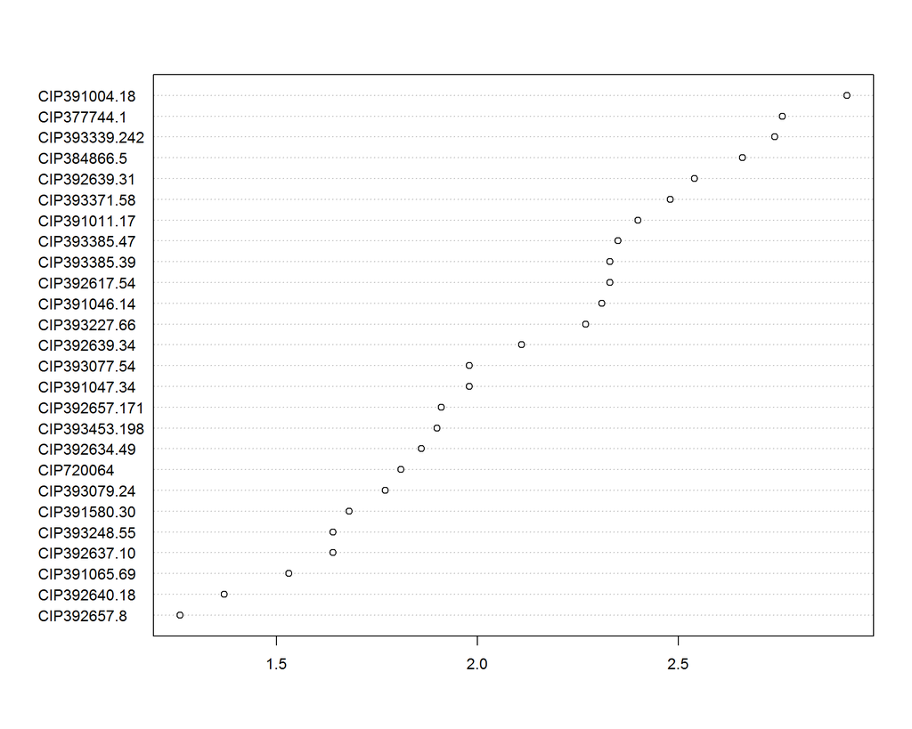

Do not forget the assumptions of the model. It is supposed that the error has a normal distribution with the same variance for all the treatments. The following plots must help you evaluate this:

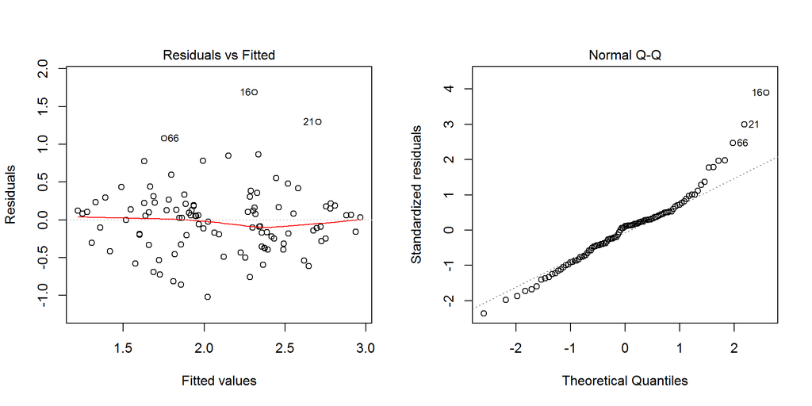

Funnel shapes for the first plot may suggest heterogeneity of variances while departures from the theoretical normal line are symptoms of lack of normality.

### Analysis for trait TEXFR

You have fitted a linear model for a RCBD. The ANOVA table for your model is:

Table continues below

|  | Df | Sum Sq | Mean Sq | F value |
| --- | --- | --- | --- | --- |
| **INSTN** | 25 | 15.2904 | 0.611617 | 8.70487 |
| **REP** | 3 | 0.0254803 | 0.00849344 | 0.120883 |
| **Residuals** | 75 | 5.26961 | 0.0702614 | NA |

|  | Pr(>F) |
| --- | --- |
| **INSTN** | 1.30798e-13 |
| **REP** | 0.94754 |
| **Residuals** | NA |

The p-value for treatments is 0.000000000000130798 which is significant at the 5% level.

The means of your treatments are:

| INSTN | TEXFR |
| --- | --- |
| CIP377744.1 | 2 |
| CIP384866.5 | 1.9 |
| CIP391004.18 | 1.81 |
| CIP391011.17 | 1.1 |
| CIP391046.14 | 1.57 |
| CIP391047.34 | 1.7 |
| CIP391065.69 | 1.9 |
| CIP391580.30 | 1.29 |
| CIP392617.54 | 1.82 |
| CIP392634.49 | 1.17 |
| CIP392637.10 | 1.17 |
| CIP392639.31 | 1.77 |
| CIP392639.34 | 2.05 |
| CIP392640.18 | 1.07 |
| CIP392657.171 | 1.09 |
| CIP392657.8 | 2.52 |
| CIP393077.54 | 1.66 |
| CIP393079.24 | 1.3 |
| CIP393227.66 | 1.13 |
| CIP393248.55 | 1.52 |
| CIP393339.242 | 1.94 |
| CIP393371.58 | 1.83 |
| CIP393385.39 | 1.86 |
| CIP393385.47 | 1.35 |
| CIP393453.198 | 2.27 |
| CIP720064 | 1.74 |

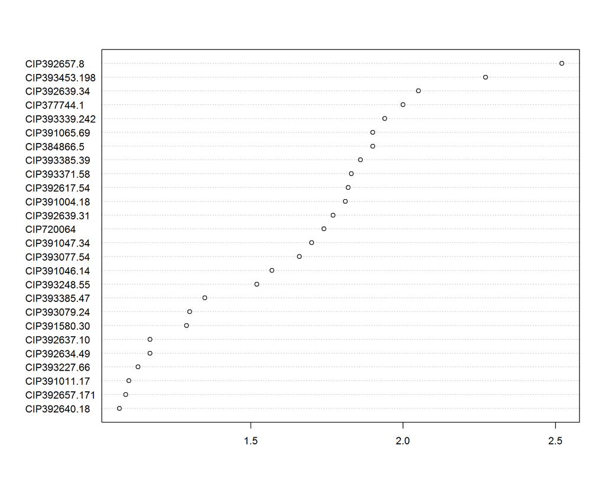

Do not forget the assumptions of the model. It is supposed that the error has a normal distribution with the same variance for all the treatments. The following plots must help you evaluate this:

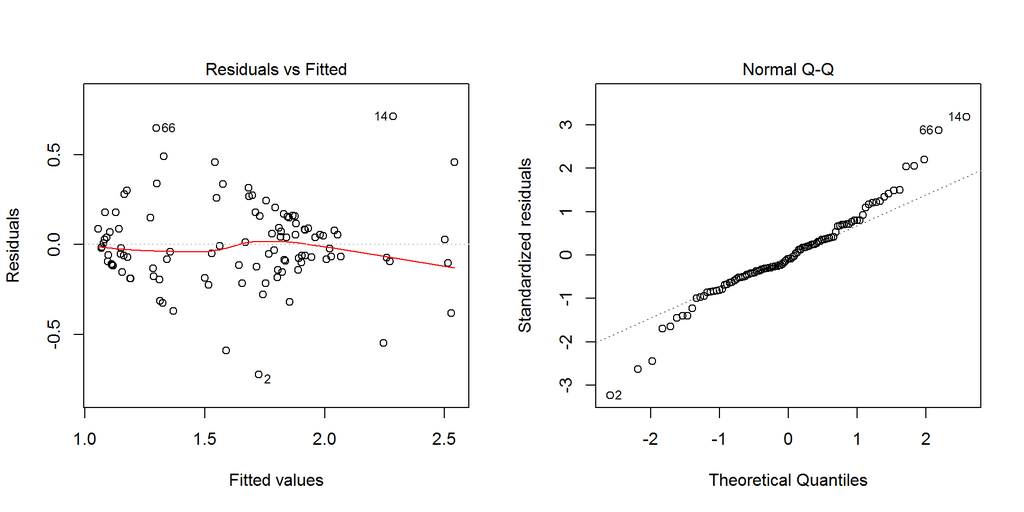

Funnel shapes for the first plot may suggest heterogeneity of variances while departures from the theoretical normal line are symptoms of lack of normality.

### Analysis for trait Chip_Color

You have fitted a linear model for a RCBD. The ANOVA table for your model is:

Table continues below

|  | Df | Sum Sq | Mean Sq | F value |
| --- | --- | --- | --- | --- |
| **INSTN** | 25 | 13.2828 | 0.531313 | 3.05508 |
| **REP** | 3 | 0.0395958 | 0.0131986 | 0.0758927 |
| **Residuals** | 75 | 13.0433 | 0.173911 | NA |

|  | Pr(>F) |
| --- | --- |
| **INSTN** | 0.000102373 |
| **REP** | 0.972804 |
| **Residuals** | NA |

The p-value for treatments is 0.000102373 which is significant at the 5% level.

The means of your treatments are:

| INSTN | Chip_Color |
| --- | --- |
| CIP377744.1 | 1.82 |
| CIP384866.5 | 2.1 |
| CIP391004.18 | 2.3 |
| CIP391011.17 | 1.15 |
| CIP391046.14 | 1.95 |
| CIP391047.34 | 1.4 |
| CIP391065.69 | 1.46 |
| CIP391580.30 | 1.64 |
| CIP392617.54 | 2.38 |
| CIP392634.49 | 1.99 |
| CIP392637.10 | 1.66 |
| CIP392639.31 | 1.97 |
| CIP392639.34 | 1.4 |
| CIP392640.18 | 1.77 |
| CIP392657.171 | 1.35 |
| CIP392657.8 | 1.19 |
| CIP393077.54 | 1.78 |
| CIP393079.24 | 2.09 |
| CIP393227.66 | 2.16 |
| CIP393248.55 | 1.42 |
| CIP393339.242 | 2.05 |
| CIP393371.58 | 2.08 |
| CIP393385.39 | 2.01 |
| CIP393385.47 | 2.05 |
| CIP393453.198 | 2.48 |
| CIP720064 | 2.01 |

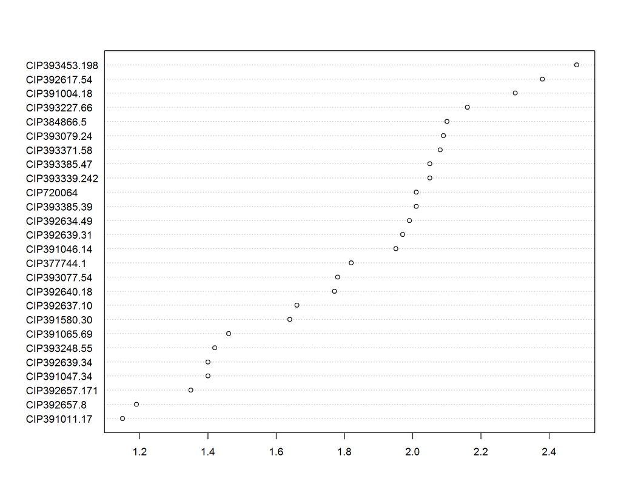

Do not forget the assumptions of the model. It is supposed that the error has a normal distribution with the same variance for all the treatments. The following plots must help you evaluate this:

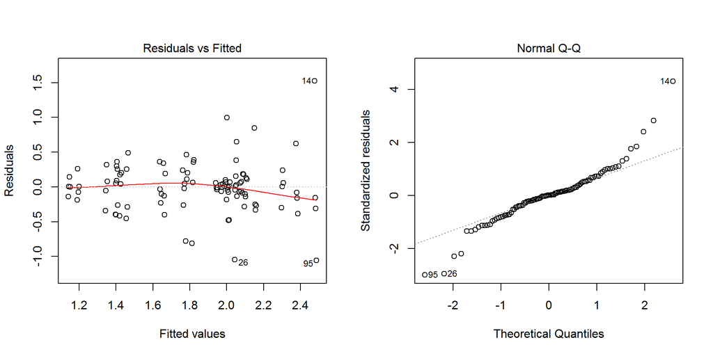

Funnel shapes for the first plot may suggest heterogeneity of variances while departures from the theoretical normal line are symptoms of lack of normality.

### Analysis for trait LB3

You have fitted a linear model for a RCBD. The ANOVA table for your model is:

|  | Df | Sum Sq | Mean Sq | F value | Pr(>F) |
| --- | --- | --- | --- | --- | --- |
| **INSTN** | 25 | 15339.7 | 613.587 | 13.7459 | 5.74463e-19 |
| **REP** | 3 | 458.413 | 152.804 | 3.42321 | 0.0214143 |
| **Residuals** | 75 | 3347.84 | 44.6378 | NA | NA |

The p-value for treatments is 0.000000000000000000574463 which is significant at the 5% level.

The means of your treatments are:

| INSTN | LB3 |
| --- | --- |
| CIP377744.1 | 12.5 |
| CIP384866.5 | 30 |
| CIP391004.18 | 5 |
| CIP391011.17 | 10 |
| CIP391046.14 | 47.5 |
| CIP391047.34 | 17.5 |
| CIP391065.69 | 16.2 |
| CIP391580.30 | 15 |
| CIP392617.54 | 3.75 |
| CIP392634.49 | 6.25 |
| CIP392637.10 | 6.25 |
| CIP392639.31 | 31.2 |
| CIP392639.34 | 31.2 |
| CIP392640.18 | 5 |
| CIP392657.171 | 10 |
| CIP392657.8 | 36.2 |
| CIP393077.54 | 5 |
| CIP393079.24 | 7.5 |
| CIP393227.66 | 8.75 |
| CIP393248.55 | 12.5 |
| CIP393339.242 | 5 |
| CIP393371.58 | 3.75 |
| CIP393385.39 | 20 |
| CIP393385.47 | 6.25 |
| CIP393453.198 | 13.8 |
| CIP720064 | 37.5 |

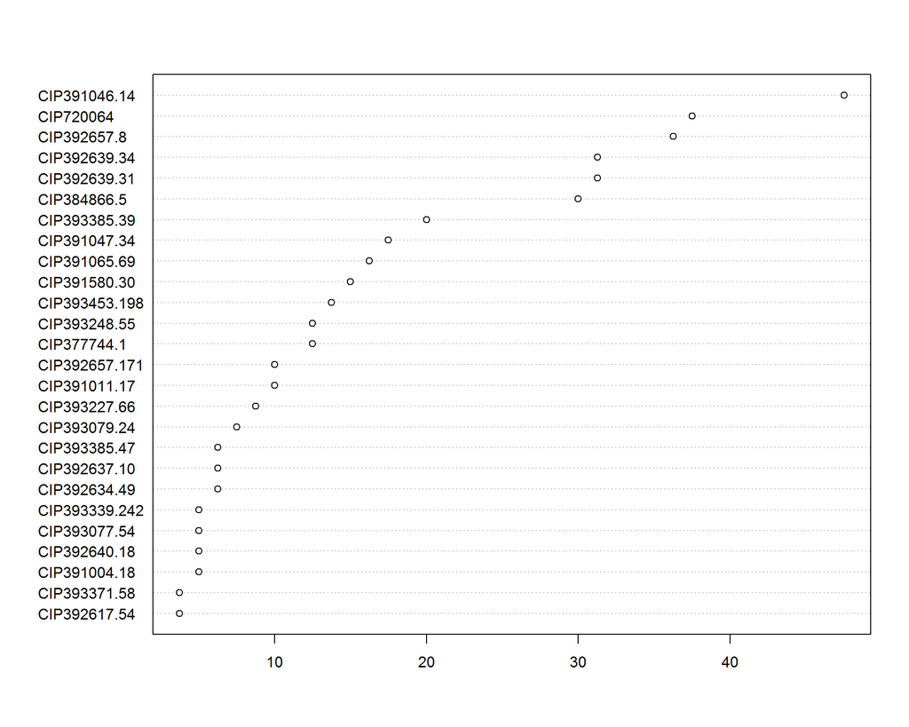

Do not forget the assumptions of the model. It is supposed that the error has a normal distribution with the same variance for all the treatments. The following plots must help you evaluate this:

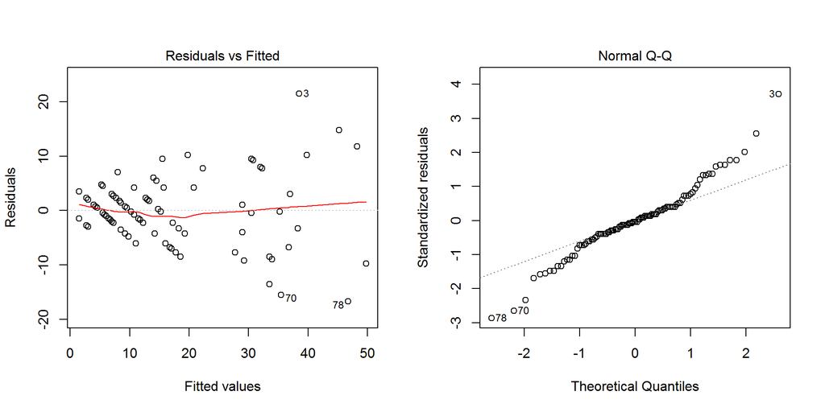

Funnel shapes for the first plot may suggest heterogeneity of variances while departures from the theoretical normal line are symptoms of lack of normality.

## Trait correlations

## Variety candidate selection

# Summary

# References

## Data sources

## Literature